# Data Frame Summary

### Data Frame Summary

#### .

**N**: 31044

**No**

**Variable**

**Stats / Values**

**Freqs (% of Valid)**

**Graph**

**Valid**

**Missing**

1

parent_company_name [character]

1. Electronic Arts 2. Zynga 3. Netmarble 4. Activision Blizzard 5. Rovio 6. Supercell 7. Glu 8. Caesars Entertainment 9. Churchill Downs 10. Outfit7 [ 115 others ]

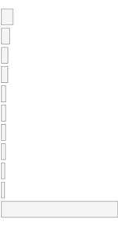

31044 (100%)

0 (0%)

2

revenue [numeric]

mean (sd) : 224167.34 (491769.01) min < med < max : 1689 < 74224 < 8241490 IQR (CV) : 205994.25 (2.19)

28631 distinct val.

31044 (100%)

0 (0%)

3

download [numeric]

mean (sd) : 47802.28 (51825.14) min < med < max : 34 < 31459.5 < 1260638 IQR (CV) : 42650.5 (1.08)

26031 distinct val.

31044 (100%)

0 (0%)

4

net_AU [numeric]

mean (sd) : 376973.53 (716689.63) min < med < max : 1 < 168181.5 < 7531427 IQR (CV) : 241545.75 (1.9)

29931 distinct val.

31044 (100%)

0 (0%)

5

year [numeric]

mean (sd) : 2016.16 (0.74) min < med < max : 2015 < 2016 < 2017 IQR (CV) : 1 (0)

2015 : 6448 (20.8%) 2016 : 13104 (42.2%) 2017 : 11492 (37.0%)

31044 (100%)

0 (0%)

6

avg_time_per_user [numeric]

mean (sd) : 6189.91 (6013.34) min < med < max : 67 < 4792 < 74108 IQR (CV) : 5542 (0.97)

12759 distinct val.

31044 (100%)

0 (0%)

7

avg_sessions_per_user [numeric]

mean (sd) : 16.62 (12.43) min < med < max : 1.04 < 13.59 < 146.53 IQR (CV) : 12.74 (0.75)

5029 distinct val.

31044 (100%)

0 (0%)

8

avg_session_duration [numeric]

mean (sd) : 365.32 (184.53) min < med < max : 20 < 336 < 1923 IQR (CV) : 232 (0.51)

1147 distinct val.

31044 (100%)

0 (0%)

9

install_penetration [numeric]

mean (sd) : 1.5 (2.06) min < med < max : 0.06 < 0.78 < 21.95 IQR (CV) : 1.27 (1.37)

30811 distinct val.

31044 (100%)

0 (0%)

10

cat_history [factor]

1. -3 2. -2 3. -1 4. 0 5. 1 6. 2 7. 3 8. 4 9. 5 10. 6 [ 3 others ]

0 ( 0.0%) 0 ( 0.0%) 0 ( 0.0%) 3188 (10.3%) 8217 (26.5%) 7507 (24.2%) 6136 (19.8%) 3780 (12.2%) 1708 ( 5.5%) 356 ( 1.1%) 152 ( 0.5%)

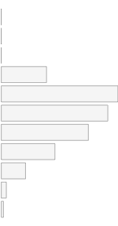

31044 (100%)

0 (0%)

11

cat_franchise [character]

1. Original 2. Spinoff

25376 (81.7%) 5668 (18.3%)

31044 (100%)

0 (0%)

12

cat_hqcountry [character]

1. East Asia 2. North America 3. North Europe 4. Other Asia 5. Other Countries 6. Other Europe 7. South America 8. West Europe

2184 ( 7.1%) 13676 (44.2%) 3744 (12.1%) 312 ( 1.0%) 3068 ( 9.9%) 728 ( 2.4%) 1040 ( 3.4%) 6188 (20.0%)

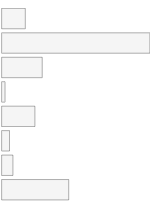

30940 (99.66%)

104 (0.34%)

13

cat_initial_base [factor]

1. (0,5e+05] 2. (5e+05,1e+06] 3. (1e+06,5e+06] 4. (5e+06,3e+07]

8424 (27.2%) 7332 (23.7%) 11908 (38.5%) 3276 (10.6%)

30940 (99.66%)

104 (0.34%)

14

cat_platform [character]

1. us_AOS 2. us_iOS

12376 (39.9%) 18668 (60.1%)

31044 (100%)

0 (0%)

Generated by summarytools package version 0.8.2 ([R](https://www.r-project.org/) version 3.4.3)  
2018-02-24